# Tarea 2

Autor/a

Kenneth Chaves Cruz

# Introducción

El análisis de la temperatura del aire en diferentes estaciones meteorológicas facilita la comparación de las condiciones observadas entre regiones.

En este trabajo se analizan datos preliminares de temperatura máxima y mínima del 17 de agosto de 2026, correspondientes a estaciones meteorológicas de Costa Rica. Los datos fueron obtenidos del Instituto Meteorológico Nacional (IMN) e incluyen el nombre y la ubicación de cada estación, la región climática, las temperaturas máxima y mínima en grados Celsius y la hora de toma de los datos (IMN, s.f).

A partir de esta información se busca responder las siguientes preguntas:

1. ¿Cómo se distribuyen las temperaturas máximas registradas entre las estaciones meteorológicas?
2. ¿Cómo varía la temperatura máxima promedio entre las regiones climáticas representadas en los datos?
3. ¿Qué relación existe entre la temperatura máxima y la temperatura mínima registradas en cada estación?

Para responderlas se utilizarán una tabla interactiva y gráficos que permitan explorar y comparar los registros. Los resultados describen las estaciones y la fecha incluidas en el archivo; por lo tanto, no representan promedios climatológicos.

# Importación y preparación de los datos

## Carga de paquetes

Se cargan los paquetes necesarios para importar, explorar y analizar los datos, y para crear tablas y gráficos interactivos.

```r
library(tidyverse)
library(sf)
library(plotly)
library(DT)
library(readxl)
library(ggplot2)
```

## Importacion de los datos

Para poder cargar los datos se tuvo que realizar unos pasos adicionales a los realizados en clase ya que no tenia un archivo CSV y si convertia el archivo original a CSV daba un error ya que se perdian datos.

```r
url <- "https://raw.githubusercontent.com/kchavesc/Tarea-2/main/temp_trd.xlsx"
# Debido a que el archivo original es en formato .xlsx use el codigo a continuación
# para poder usar ese archivo, ya que si lo pasaba a .CSV perdia formato y se hacia un
# desastre
archivo_temporal <- tempfile(fileext = ".xlsx")
download.file(url, archivo_temporal, mode = "wb")
temperatura <- read_excel(archivo_temporal, skip = 3)
# head me permite explorar las primeras lineas del archivo.
head(temperatura)
```

```
# A tibble: 6 × 7
  Estación            Longitud Latitud `Región Climática` Temperatura Máxima (…¹
  <chr>                  <dbl>   <dbl> <chr>                               <dbl>
1 Dulce Nombre Nicoya    -85.5   10.1  Pacífico Norte                       34.3
2 Guayabal Mastate       -84.6    9.92 Pacífico Norte                       30.8
3 Aeropuerto Tobías …    -84.1    9.96 Valle Central                        29.3
4 Aeropuerto Juan Sa…    -84.2    9.99 Valle Central                        29.1
5 Asada Sardinal         -85.7   10.5  Pacífico Norte                       34.6
6 Asada Guayabo (Bag…    -85.2   10.7  Pacífico Norte                       27
# ℹ abbreviated name: ¹`Temperatura Máxima (°C)`
# ℹ 2 more variables: `Temperatura Mínima (°C)` <dbl>,
#   `Hora Toma de datos` <chr>
```

# Tabla interactiva

La siguiente tabla presenta las temperaturas máximas y mínimas registradas en las estaciones meteorológicas, junto con su ubicación, región climática y hora de toma de datos. La información corresponde al 17 de agosto de 2026 y tiene carácter preliminar.

```r
# El siguiente código crea la tabla interactiva y me permite asignar los
# nombres en español, ya que por defecto los muestra en inglés
datatable(
  temperatura,
  rownames = FALSE,
  options = list(
    language = list(
      search = "Buscar:",
      lengthMenu = "Mostrar _MENU_ registros",
      info = "Mostrando _START_ a _END_ de _TOTAL_ registros",
      infoEmpty = "No hay registros disponibles",
      infoFiltered = "(filtrado de _MAX_ registros)",
      zeroRecords = "No se encontraron registros",
      paginate = list(
        previous = "Anterior",
        `next` = "Siguiente"
      )
    )
  )
) |> # Las siguientes lineas permiten definir la cantidad de decimales
  formatRound(
    columns = c("Longitud", "Latitud"),
    digits = 3,
    mark = ".",
    dec.mark = ","
  ) |>
  formatRound(
    columns = c("Temperatura Máxima (°C)", "Temperatura Mínima (°C)"),
    digits = 1,
    mark = ".",
    dec.mark = ","
  )
```

| Estación | Longitud | Latitud | Región Climática | Temperatura Máxima (°C) | Temperatura Mínima (°C) | Hora Toma de datos |
| --- | --- | --- | --- | --- | --- | --- |
| Dulce Nombre Nicoya | -85.466667 | 10.083333 | Pacífico Norte | 34.3 | 21.1 | 17/08/2026 04:28:27 p.âm. |
| Guayabal Mastate | -84.5685 | 9.917 | Pacífico Norte | 30.8 | 21.6 | 17/08/2026 04:24:06 p.âm. |
| Aeropuerto Tobías Bolaños | -84.139167 | 9.956617 | Valle Central | 29.3 | 18.5 | 17/08/2026 04:26:21 p.âm. |
| Aeropuerto Juan Santamaría | -84.218611 | 9.989167 | Valle Central | 29.1 | 18.7 | 17/08/2026 04:35:51 p.âm. |
| Asada Sardinal | -85.696033 | 10.506767 | Pacífico Norte | 34.6 | 23.5 | 17/08/2026 04:32:00 p.âm. |
| Asada Guayabo (Bagaces) | -85.201167 | 10.715222 | Pacífico Norte | 27 | 22.8 | 17/08/2026 04:34:33 p.âm. |
| Asada Pilangosta | -85.405925 | 10.031847 | Pacífico Norte | 31.6 | 21.2 | 17/08/2026 04:20:18 p.âm. |
| Altamira | -83.007778 | 9.029167 | Pacífico Sur | 22.6 | 15.4 | 17/08/2026 04:23:48 p.âm. |
| Barco Quebrado | -85.614544 | 9.916047 | Pacífico Norte | 32.4 | 23 | 17/08/2026 04:29:06 p.âm. |
| Barú | -83.881472 | 9.271389 | Pacífico Central | 30.9 | 23 | 17/08/2026 04:42:00 p.m. |

[output cut: 84 more lines]

# Gráficos

Se generan un histograma, un gráfico de barras y uno de dispersión interactivo.

## Histograma

El siguiente histograma muestra la distribución de las temperaturas máximas registradas en las estaciones meteorológicas del país.

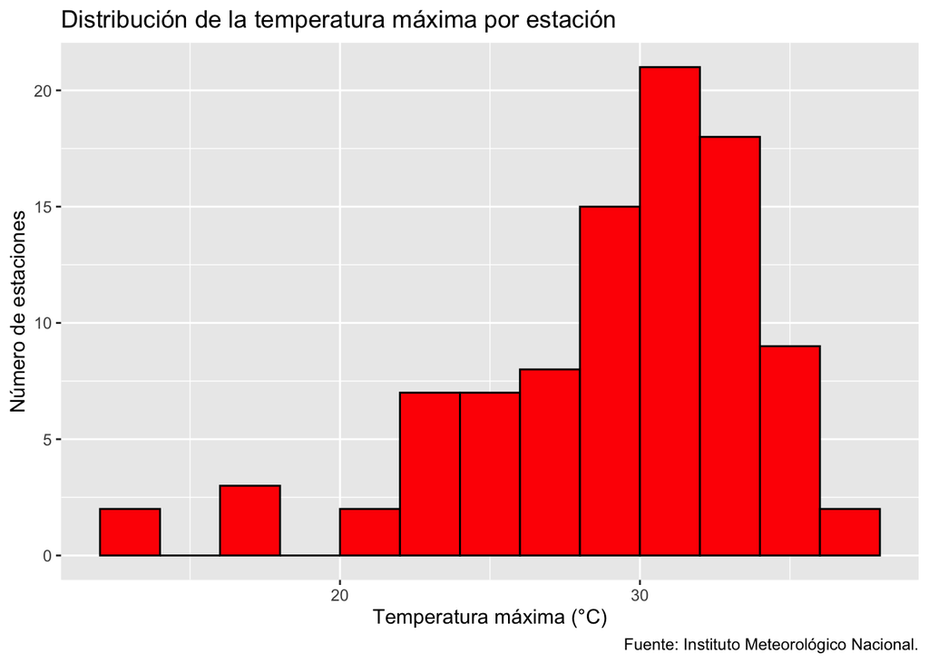

```r
ggplot(temperatura, aes(x = `Temperatura Máxima (°C)`)) +
  geom_histogram(binwidth = 2, boundary = 0, fill = "red", color = "black") +
  labs(
    title = "Distribución de la temperatura máxima por estación",
    x = "Temperatura máxima (°C)",
    y = "Número de estaciones",
    caption = "Fuente: Instituto Meteorológico Nacional."
  )
```

Se observa que poco más de 20 estaciones registraron temperaturas máximas entre 30 y 32 °C, mientras que alrededor de 17 presentaron temperaturas entre los 32 - 34 °C.

## Gráfico de barras

El siguiente gráfico de barras muestra el promedio de la temperatura máxima por región climática.

```r
# El siguiente código agrupa las regiones climáticas y calcula el valor
#promedio de la tempet\ratura máxima
promedio_regiones <- temperatura |>
  group_by(`Región Climática`) |>
  summarize(
    temperatura_promedio = mean(`Temperatura Máxima (°C)`, na.rm = TRUE)
  )
```

Una vez obtenido el promedio se procede a gráficar los datos.

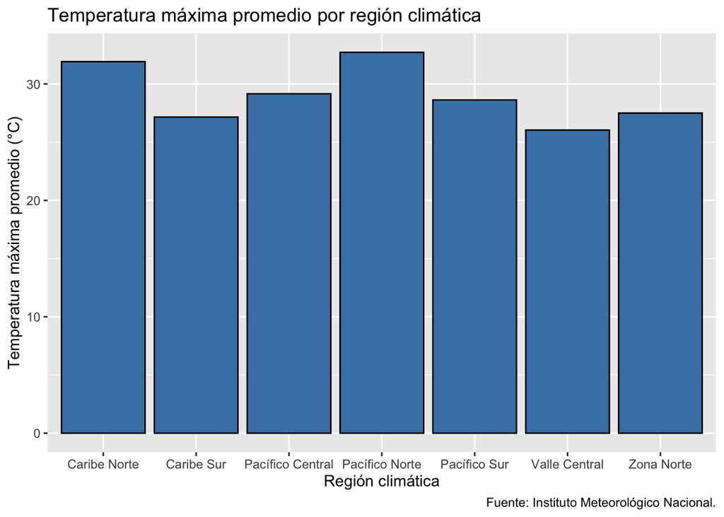

```r
#| label: gráfico de barras
ggplot(
  promedio_regiones,
  aes(x = `Región Climática`, y = temperatura_promedio)
) +
  geom_col(fill = "steelblue", color = "black") +
  labs(
    title = "Temperatura máxima promedio por región climática",
    x = "Región climática",
    y = "Temperatura máxima promedio (°C)",
    caption = "Fuente: Instituto Meteorológico Nacional."
  )
```

Se aprecia claramente como la temperatura máxima promedio más alta se presenta en el Pacífico Norte y el Valle Central y Caribe Sur con valores más frescos.

## Dispersión interactivo

El suguiente es un gráfico de dispersión interactivo. Cada punto representaría una estación; al colocar el cursor encima, se mostrarían su nombre, región y temperaturas máxima y mínima.

```r
grafico_dispersion <- ggplot(
  temperatura,
  aes(
    x = `Temperatura Mínima (°C)`,
    y = `Temperatura Máxima (°C)`,
    text = paste( # aqui se define el nombre de las etiquetas y el valor
                 # que va a mostrar
      "Estación:", Estación,
      "<br>Región:", `Región Climática`,
      "<br>Temperatura mínima:", `Temperatura Mínima (°C)`, "°C",
      "<br>Temperatura máxima:", `Temperatura Máxima (°C)`, "°C"
    )
  )
) +
  geom_point(color = "steelblue", size = 2, alpha = 0.8) +
  labs(
    title = "Temperaturas máxima y mínima por estación",
    x = "Temperatura mínima (°C)",
    y = "Temperatura máxima (°C)",
    caption = "Fuente: Instituto Meteorológico Nacional."
  )

ggplotly(grafico_dispersion, tooltip = "text") |>
  config(displaylogo = FALSE)
```

[interactive chart not shown]

Figura 1

Se aprecia como la relación entre máxima y mínima es más alta en el Pacifico Norte y más baja en las zonas montañosas.

# Conclusiones

El análisis de los datos preliminares de temperatura del 17 de agosto de 2026 permitió comparar las condiciones registradas en las estaciones meteorológicas incluidas en el archivo.

En cuanto a la distribución de la temperatura máxima, el histograma muestra que la mayor cantidad de estaciones registró valores entre 30°C - 32°C. Por otro lado, las temperaturas máximas menos frecuentes se encontraron en los extremos del histograma.

Finalmente, el gráfico de dispersión muestra que la relación entre máximas y mínimas es mayor en el Pacífico Norte y menor en las zonas montañosas.

Como limitaciones, los datos corresponden a una única fecha y tienen carácter preliminar. Además, la cantidad y distribución de las estaciones pueden ser diferentes entre regiones. Por ello, los resultados describen únicamente los registros analizados y no deben interpretarse como promedios climatológicos ni como una caracterización completa de cada región.

# Referencias

Instituto Meteorológico Nacional. (s. f.). *Instituto Meteorológico Nacional de Costa Rica.*  
https://www.imn.ac.cr/web/imn/inicio

# Declaración de uso de IA

Para la elaboración de este trabajo se utilizó ChatGPT como apoyo en la explicación y corrección de código en R, principalmente para la importación de los datos desde GitHub ya que los datos no se tenían en formato CSV y en clase no se vio como cargar datos de otro tipo de archivo. También se utilizó para depurar código de la tabla interactiva y la creación de los gráficos. Adicionalmente se utilizó para orientar la estructura del documento y mejorar la redacción de algunos apartados.

El código y los resultados fueron revisados por el autor, quien es responsable de su comprensión, interpretación y presentación final.